# Exam 1

## Exam 1

#### Metainformation

1. | Tag | Value |
   | --- | --- |
   | `file` | Reliability_vufsw-cronbach'salpha-0026-nl_vufsw-cronbach'salpha-0026-nl |
   | `name` | vufsw-cronbach'salpha-0026-nl |
   | `section` | reliability/analysis/cronbach's alpha |
   | `type` | schoice |
   | `solution` | FALSE, FALSE, TRUE, FALSE, FALSE |
   | `Type` | interpretating output |
   | `Program` | NA |
   | `Language` | dutch |
   | `Level` | statistical reasoning |

#### Question

   Stel, we krijgen de onderstaande uitkomsten bij een betrouwbaarheidsanalyse van een schaal met 7 stellingen. Wat kunnen we het beste met **item5** doen? En waarom?

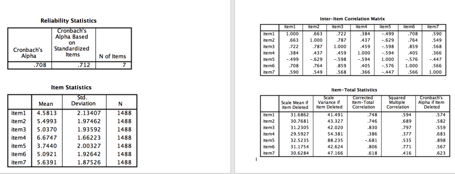

   1. **FALSE:** Dit item kunnen we het beste ongewijzigd in de schaal **behouden**, omdat de waarde bij “Cronbach’s Alpha if Item Deleted” hoger is dan 0,80.
   2. **FALSE:** Dit item kunnen we het beste uit de schaal **verwijderen**, omdat de Item-Total Correlatie een hoge negatieve waarde heeft.
   3. **TRUE:** Dit item kunnen we het beste **ompolen** (hercoderen), omdat de Item-Total Correlatie een hoge negatieve waarde heeft.
   4. **FALSE:** Dit item kunnen we het beste **standaardiseren**, omdat de z-score van item5 zodoende een hoge positieve Item-Total Correlatie zal hebben.
   5. **FALSE:** Dit item kunnen we het beste uit de schaal **verwijderen**, omdat de waarde bij “Cronbach’s Alpha if Item Deleted” hoger is dan 0,80.